# Data - 624 - Project 2

Abdelmalek Hajjam, Monu Chacko, Paul Perez

5/22/2021

# 1 Project Problem Statement

This is role playing. I am your new boss. I am in charge of production at ABC Beverage and you are a team of data scientists reporting to me. My leadership has told me that new regulations are requiring us to understand our manufacturing process, the predictive factors and be able to report to them our predictive model of PH.

Please use the historical data set I am providing. Build and report the factors in BOTH a technical and non-technical report. I like to use Word and Excel. Please provide your non-technical report in a business friendly readable document and your predictions in an Excel readable format. The technical report should show clearly the models you tested and how you selected your final approach.

Please submit both Rpubs links and .rmd files or other readable formats for technical and non-technical reports. Also submit the excel file showing the prediction of your models for pH.

# 2 Executive Summary

New Regulations by ABC beverage company leadership requires the company’s production unit to better understand the manufacturing process, the predictive factors and their relationship to the PH of the beverages.

# 3 Research Statement

The research is an effort to find the predictive variables related to the ph of the beverages and build the predictive model for ph of beverages

# 4 Data Collection

The dataset is a historic data containing predictors associated to the PH and is provided in an excel file. We will utilize this historic dataset to analyze and predict the PH of beverages. Two excel files are provided:

- The training data (StudentData.xlsx)
- The test data (StudentEvaluation.xlsx)

## 4.1 Load Data

```r
student_data_tr <- read.csv("https://raw.githubusercontent.com/monuchacko/cuny_msds/master/data_624/data/StudentData.csv", stringsAsFactors = FALSE)
student_data_eval <- read.csv("https://raw.githubusercontent.com/monuchacko/cuny_msds/master/data_624/data/StudentEvaluation.csv", stringsAsFactors = FALSE)
```

# 5 Explore Data

Initially, we’ll do a cursory exploration of the data. After that, we’ll iteratively prepare and explore the data, wherever required.

```r
dim1 <- dim(student_data_tr)

#Number of rows
dim1[1]
```

```
## [1] 2571
```

```r
#Number of columns
dim1[2]
```

```
## [1] 33
```

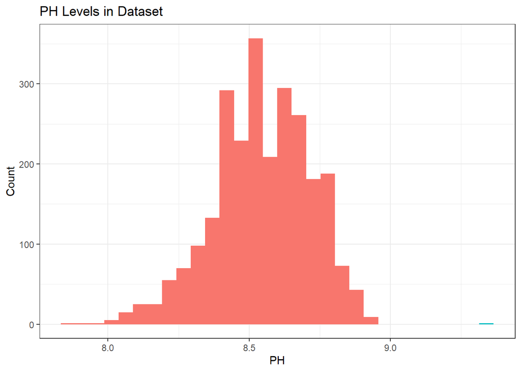

```r
student_data_tr %>%
  ggplot(aes(PH, fill=PH > 9)) +
  geom_histogram(bins=30) +
  theme_bw() +
  theme(legend.position='center') +
  labs(y='Count', title='PH Levels in Dataset')
```

View training set sample

```r
head(student_data_tr) %>%
  kable() %>%
    kable_styling()
```

| Brand.Code | Carb.Volume | Fill.Ounces | PC.Volume | Carb.Pressure | Carb.Temp | PSC | PSC.Fill | PSC.CO2 | Mnf.Flow | Carb.Pressure1 | Fill.Pressure | Hyd.Pressure1 | Hyd.Pressure2 | Hyd.Pressure3 | Hyd.Pressure4 | Filler.Level | Filler.Speed | Temperature | Usage.cont | Carb.Flow | Density | MFR | Balling | Pressure.Vacuum | PH | Oxygen.Filler | Bowl.Setpoint | Pressure.Setpoint | Air.Pressurer | … |
| --- | --- | --- | --- | --- | --- | --- | --- | --- | --- | --- | --- | --- | --- | --- | --- | --- | --- | --- | --- | --- | --- | --- | --- | --- | --- | --- | --- | --- | --- | --- |
| B | 5.340000 | 23.96667 | 0.2633333 | 68.2 | 141.2 | 0.104 | 0.26 | 0.04 | -100 | 118.8 | 46.0 | 0 | NA | NA | 118 | 121.2 | 4002 | 66.0 | 16.18 | 2932 | 0.88 | 725.0 | 1.398 | -4.0 | 8.36 | 0.022 | 120 | 46.4 | 142.6 | … |
| A | 5.426667 | 24.00667 | 0.2386667 | 68.4 | 139.6 | 0.124 | 0.22 | 0.04 | -100 | 121.6 | 46.0 | 0 | NA | NA | 106 | 118.6 | 3986 | 67.6 | 19.90 | 3144 | 0.92 | 726.8 | 1.498 | -4.0 | 8.26 | 0.026 | 120 | 46.8 | 143.0 | … |
| B | 5.286667 | 24.06000 | 0.2633333 | 70.8 | 144.8 | 0.090 | 0.34 | 0.16 | -100 | 120.2 | 46.0 | 0 | NA | NA | 82 | 120.0 | 4020 | 67.0 | 17.76 | 2914 | 1.58 | 735.0 | 3.142 | -3.8 | 8.94 | 0.024 | 120 | 46.6 | 142.0 | … |
| A | 5.440000 | 24.00667 | 0.2933333 | 63.0 | 132.6 | NA | 0.42 | 0.04 | -100 | 115.2 | 46.4 | 0 | 0 | 0 | 92 | 117.8 | 4012 | 65.6 | 17.42 | 3062 | 1.54 | 730.6 | 3.042 | -4.4 | 8.24 | 0.030 | 120 | 46.0 | 146.2 | … |
| A | 5.486667 | 24.31333 | 0.1113333 | 67.2 | 136.8 | 0.026 | 0.16 | 0.12 | -100 | 118.4 | 45.8 | 0 | 0 | 0 | 92 | 118.6 | 4010 | 65.6 | 17.68 | 3054 | 1.54 | 722.8 | 3.042 | -4.4 | 8.26 | 0.030 | 120 | 46.0 | 146.2 | … |
| A | 5.380000 | 23.92667 | 0.2693333 | 66.6 | 138.4 | 0.090 | 0.24 | 0.04 | -100 | 119.6 | 45.6 | 0 | 0 | 0 | 116 | 120.2 | 4014 | 66.2 | 23.82 | 2948 | 1.52 | 738.8 | 2.992 | -4.4 | 8.32 | 0.024 | 120 | 46.0 | 146.6 | … |

```r
table(student_data_tr$`Brand Code`)
```

```
## < table of extent 0 >
```

```r
summary(student_data_tr)
```

```
##   Brand.Code         Carb.Volume     Fill.Ounces      PC.Volume
##  Length:2571        Min.   :5.040   Min.   :23.63   Min.   :0.07933
##  Class :character   1st Qu.:5.293   1st Qu.:23.92   1st Qu.:0.23917
##  Mode  :character   Median :5.347   Median :23.97   Median :0.27133
##                     Mean   :5.370   Mean   :23.97   Mean   :0.27712
##                     3rd Qu.:5.453   3rd Qu.:24.03   3rd Qu.:0.31200
##                     Max.   :5.700   Max.   :24.32   Max.   :0.47800
##                     NA's   :10      NA's   :38      NA's   :39
##  Carb.Pressure     Carb.Temp          PSC             PSC.Fill
##  Min.   :57.00   Min.   :128.6   Min.   :0.00200   Min.   :0.0000
##  1st Qu.:65.60   1st Qu.:138.4   1st Qu.:0.04800   1st Qu.:0.1000
##  Median :68.20   Median :140.8   Median :0.07600   Median :0.1800
##  Mean   :68.19   Mean   :141.1   Mean   :0.08457   Mean   :0.1954
##  3rd Qu.:70.60   3rd Qu.:143.8   3rd Qu.:0.11200   3rd Qu.:0.2600
##  Max.   :79.40   Max.   :154.0   Max.   :0.27000   Max.   :0.6200
##  NA's   :27      NA's   :26      NA's   :33        NA's   :23
##     PSC.CO2           Mnf.Flow       Carb.Pressure1  Fill.Pressure
##  Min.   :0.00000   Min.   :-100.20   Min.   :105.6   Min.   :34.60
##  1st Qu.:0.02000   1st Qu.:-100.00   1st Qu.:119.0   1st Qu.:46.00
##  Median :0.04000   Median :  65.20   Median :123.2   Median :46.40
##  Mean   :0.05641   Mean   :  24.57   Mean   :122.6   Mean   :47.92
##  3rd Qu.:0.08000   3rd Qu.: 140.80   3rd Qu.:125.4   3rd Qu.:50.00
##  Max.   :0.24000   Max.   : 229.40   Max.   :140.2   Max.   :60.40
##  NA's   :39        NA's   :2         NA's   :32      NA's   :22
##  Hyd.Pressure1   Hyd.Pressure2   Hyd.Pressure3   Hyd.Pressure4
##  Min.   :-0.80   Min.   : 0.00   Min.   :-1.20   Min.   : 52.00
##  1st Qu.: 0.00   1st Qu.: 0.00   1st Qu.: 0.00   1st Qu.: 86.00
##  Median :11.40   Median :28.60   Median :27.60   Median : 96.00
##  Mean   :12.44   Mean   :20.96   Mean   :20.46   Mean   : 96.29
##  3rd Qu.:20.20   3rd Qu.:34.60   3rd Qu.:33.40   3rd Qu.:102.00
##  Max.   :58.00   Max.   :59.40   Max.   :50.00   Max.   :142.00
##  NA's   :11      NA's   :15      NA's   :15      NA's   :30
##   Filler.Level    Filler.Speed   Temperature      Usage.cont      Carb.Flow
##  Min.   : 55.8   Min.   : 998   Min.   :63.60   Min.   :12.08   Min.   :  26
##  1st Qu.: 98.3   1st Qu.:3888   1st Qu.:65.20   1st Qu.:18.36   1st Qu.:1144
##  Median :118.4   Median :3982   Median :65.60   Median :21.79   Median :3028
##  Mean   :109.3   Mean   :3687   Mean   :65.97   Mean   :20.99   Mean   :2468
##  3rd Qu.:120.0   3rd Qu.:3998   3rd Qu.:66.40   3rd Qu.:23.75   3rd Qu.:3186
##  Max.   :161.2   Max.   :4030   Max.   :76.20   Max.   :25.90   Max.   :5104
##  NA's   :20      NA's   :57     NA's   :14      NA's   :5       NA's   :2
```

[output cut: 9 more lines]

```
##  Min.   :7.880   Min.   :0.00240   Min.   : 70.0   Min.   :44.00
##  1st Qu.:8.440   1st Qu.:0.02200   1st Qu.:100.0   1st Qu.:46.00
##  Median :8.540   Median :0.03340   Median :120.0   Median :46.00
##  Mean   :8.546   Mean   :0.04684   Mean   :109.3   Mean   :47.62
##  3rd Qu.:8.680   3rd Qu.:0.06000   3rd Qu.:120.0   3rd Qu.:50.00
##  Max.   :9.360   Max.   :0.40000   Max.   :140.0   Max.   :52.00
##  NA's   :4       NA's   :12        NA's   :2       NA's   :12
##  Air.Pressurer      Alch.Rel        Carb.Rel      Balling.Lvl
##  Min.   :140.8   Min.   :5.280   Min.   :4.960   Min.   :0.00
##  1st Qu.:142.2   1st Qu.:6.540   1st Qu.:5.340   1st Qu.:1.38
##  Median :142.6   Median :6.560   Median :5.400   Median :1.48
##  Mean   :142.8   Mean   :6.897   Mean   :5.437   Mean   :2.05
##  3rd Qu.:143.0   3rd Qu.:7.240   3rd Qu.:5.540   3rd Qu.:3.14
##  Max.   :148.2   Max.   :8.620   Max.   :6.060   Max.   :3.66
##                  NA's   :9       NA's   :10      NA's   :1
```

Lets examine the structure of training data set

```r
str(student_data_tr)
```

```
## 'data.frame':    2571 obs. of  33 variables:
##  $ Brand.Code       : chr  "B" "A" "B" "A" ...
##  $ Carb.Volume      : num  5.34 5.43 5.29 5.44 5.49 ...
##  $ Fill.Ounces      : num  24 24 24.1 24 24.3 ...
##  $ PC.Volume        : num  0.263 0.239 0.263 0.293 0.111 ...
##  $ Carb.Pressure    : num  68.2 68.4 70.8 63 67.2 66.6 64.2 67.6 64.2 72 ...
##  $ Carb.Temp        : num  141 140 145 133 137 ...
##  $ PSC              : num  0.104 0.124 0.09 NA 0.026 0.09 0.128 0.154 0.132 0.014 ...
##  $ PSC.Fill         : num  0.26 0.22 0.34 0.42 0.16 0.24 0.4 0.34 0.12 0.24 ...
##  $ PSC.CO2          : num  0.04 0.04 0.16 0.04 0.12 0.04 0.04 0.04 0.14 0.06 ...
##  $ Mnf.Flow         : num  -100 -100 -100 -100 -100 -100 -100 -100 -100 -100 ...
##  $ Carb.Pressure1   : num  119 122 120 115 118 ...
##  $ Fill.Pressure    : num  46 46 46 46.4 45.8 45.6 51.8 46.8 46 45.2 ...
##  $ Hyd.Pressure1    : num  0 0 0 0 0 0 0 0 0 0 ...
##  $ Hyd.Pressure2    : num  NA NA NA 0 0 0 0 0 0 0 ...
```

[output cut: 19 more lines]

There are few fields, which have missing values, which we’ll investigate in greater details later.

# 6 Data Preparation

At this stage, we’ll explore and prepare iteratively. Now, we’ll check for NA. After that if required, we’ll impute them. After that we’ll show some boxplots of the numeric fields.

Checking for NA.

```r
any(is.na(student_data_tr))
```

```
## [1] TRUE
```

NA does exist. So, we’ll impute with mice().

```r
imputed_train <- mice(student_data_tr, m = 1, method = "pmm", print = F) %>% mice::complete()
```

Rechecking for NA after imputation.

```r
any(is.na(imputed_train))
```

```
## [1] FALSE
```

We observe that NA were removed. In the following, we’ll visualize with missmap().

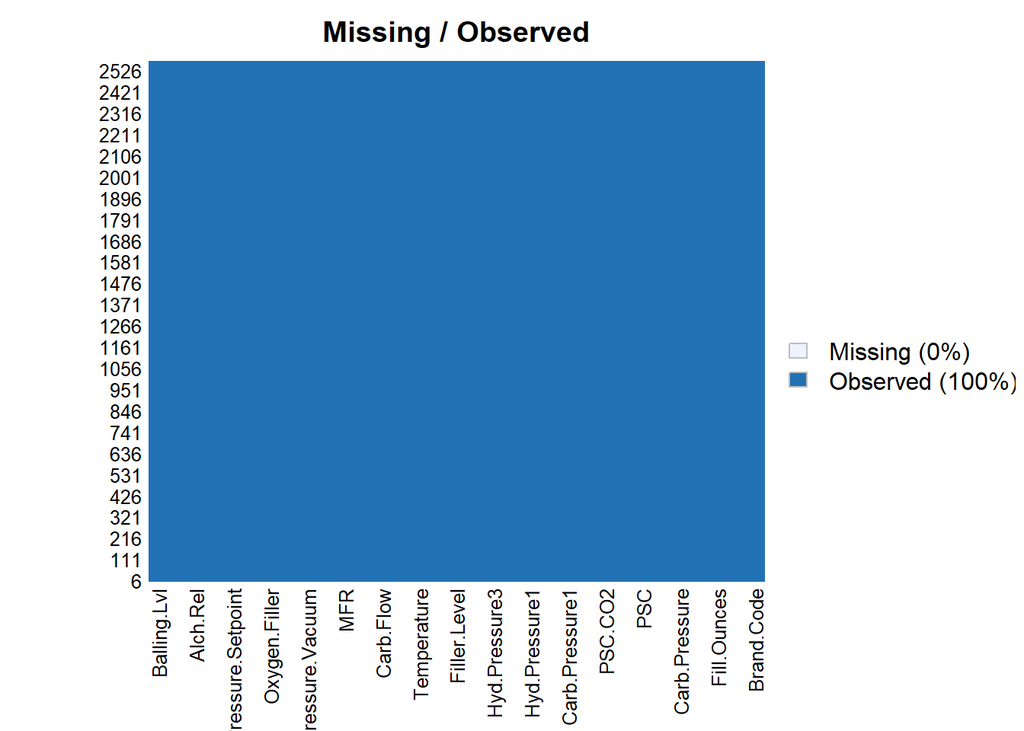

```r
imputed_train %>% missmap(main = "Missing / Observed")
```

Both is.na() and missmap() confirm that NA were eliminated.

Here, we’ll explore the data a little further. First, we’ll take a quick look at min, 1st quartile, median, mean, 2nd quartile, max etc.

```r
summary(imputed_train)
```

```
##   Brand.Code         Carb.Volume     Fill.Ounces      PC.Volume
##  Length:2571        Min.   :5.040   Min.   :23.63   Min.   :0.07933
##  Class :character   1st Qu.:5.293   1st Qu.:23.92   1st Qu.:0.23933
##  Mode  :character   Median :5.347   Median :23.97   Median :0.27133
##                     Mean   :5.370   Mean   :23.97   Mean   :0.27764
##                     3rd Qu.:5.457   3rd Qu.:24.03   3rd Qu.:0.31267
##                     Max.   :5.700   Max.   :24.32   Max.   :0.47800
##  Carb.Pressure     Carb.Temp          PSC             PSC.Fill
##  Min.   :57.00   Min.   :128.6   Min.   :0.00200   Min.   :0.0000
##  1st Qu.:65.60   1st Qu.:138.4   1st Qu.:0.04800   1st Qu.:0.1000
##  Median :68.20   Median :140.8   Median :0.07600   Median :0.1800
##  Mean   :68.22   Mean   :141.1   Mean   :0.08466   Mean   :0.1959
##  3rd Qu.:70.60   3rd Qu.:143.8   3rd Qu.:0.11200   3rd Qu.:0.2600
##  Max.   :79.40   Max.   :154.0   Max.   :0.27000   Max.   :0.6200
##     PSC.CO2           Mnf.Flow       Carb.Pressure1  Fill.Pressure
##  Min.   :0.00000   Min.   :-100.20   Min.   :105.6   Min.   :34.60
##  1st Qu.:0.02000   1st Qu.:-100.00   1st Qu.:119.0   1st Qu.:46.00
##  Median :0.04000   Median :  64.80   Median :123.2   Median :46.40
##  Mean   :0.05657   Mean   :  24.47   Mean   :122.6   Mean   :47.91
##  3rd Qu.:0.08000   3rd Qu.: 140.80   3rd Qu.:125.4   3rd Qu.:50.00
##  Max.   :0.24000   Max.   : 229.40   Max.   :140.2   Max.   :60.40
##  Hyd.Pressure1   Hyd.Pressure2   Hyd.Pressure3   Hyd.Pressure4
##  Min.   :-0.80   Min.   : 0.00   Min.   :-1.20   Min.   : 52.00
##  1st Qu.: 0.00   1st Qu.: 0.00   1st Qu.: 0.00   1st Qu.: 86.00
##  Median :11.40   Median :28.60   Median :27.40   Median : 96.00
##  Mean   :12.46   Mean   :20.94   Mean   :20.42   Mean   : 96.53
##  3rd Qu.:20.20   3rd Qu.:34.60   3rd Qu.:33.20   3rd Qu.:102.00
##  Max.   :58.00   Max.   :59.40   Max.   :50.00   Max.   :142.00
##   Filler.Level    Filler.Speed   Temperature      Usage.cont      Carb.Flow
##  Min.   : 55.8   Min.   : 998   Min.   :63.60   Min.   :12.08   Min.   :  26
##  1st Qu.: 98.3   1st Qu.:3825   1st Qu.:65.20   1st Qu.:18.36   1st Qu.:1151
##  Median :118.4   Median :3980   Median :65.60   Median :21.78   Median :3028
##  Mean   :109.2   Mean   :3639   Mean   :65.97   Mean   :20.99   Mean   :2469
##  3rd Qu.:120.0   3rd Qu.:3997   3rd Qu.:66.40   3rd Qu.:23.76   3rd Qu.:3187
##  Max.   :161.2   Max.   :4030   Max.   :76.20   Max.   :25.90   Max.   :5104
##     Density           MFR           Balling       Pressure.Vacuum
##  Min.   :0.240   Min.   : 31.4   Min.   :-0.170   Min.   :-6.600
##  1st Qu.:0.900   1st Qu.:695.0   1st Qu.: 1.496   1st Qu.:-5.600
##  Median :0.980   Median :721.4   Median : 1.648   Median :-5.400
##  Mean   :1.174   Mean   :672.5   Mean   : 2.198   Mean   :-5.216
##  3rd Qu.:1.620   3rd Qu.:730.4   3rd Qu.: 3.292   3rd Qu.:-5.000
##  Max.   :1.920   Max.   :868.6   Max.   : 4.012   Max.   :-3.600
##        PH        Oxygen.Filler     Bowl.Setpoint   Pressure.Setpoint
##  Min.   :7.880   Min.   :0.00240   Min.   : 70.0   Min.   :44.00
##  1st Qu.:8.440   1st Qu.:0.02200   1st Qu.:100.0   1st Qu.:46.00
##  Median :8.540   Median :0.03340   Median :120.0   Median :46.00
##  Mean   :8.546   Mean   :0.04702   Mean   :109.3   Mean   :47.61
##  3rd Qu.:8.680   3rd Qu.:0.06000   3rd Qu.:120.0   3rd Qu.:50.00
##  Max.   :9.360   Max.   :0.40000   Max.   :140.0   Max.   :52.00
##  Air.Pressurer      Alch.Rel        Carb.Rel      Balling.Lvl
##  Min.   :140.8   Min.   :5.280   Min.   :4.960   Min.   :0.00
##  1st Qu.:142.2   1st Qu.:6.540   1st Qu.:5.340   1st Qu.:1.38
##  Median :142.6   Median :6.560   Median :5.400   Median :1.48
##  Mean   :142.8   Mean   :6.897   Mean   :5.436   Mean   :2.05
##  3rd Qu.:143.0   3rd Qu.:7.230   3rd Qu.:5.540   3rd Qu.:3.14
##  Max.   :148.2   Max.   :8.620   Max.   :6.060   Max.   :3.66
```

## 6.1 Boxplots

Box plots for the variables reveal, that besides having the outliers in the variables, most of the variables are skewed. For example: Variables density, carb flow, filler speed and oxygen filler are skewed providing us an opportunity to further check their distribution.

First look at the boxplots.

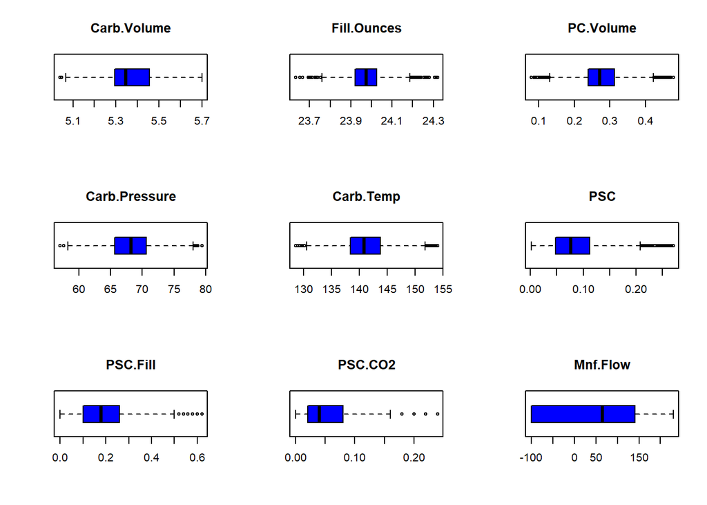

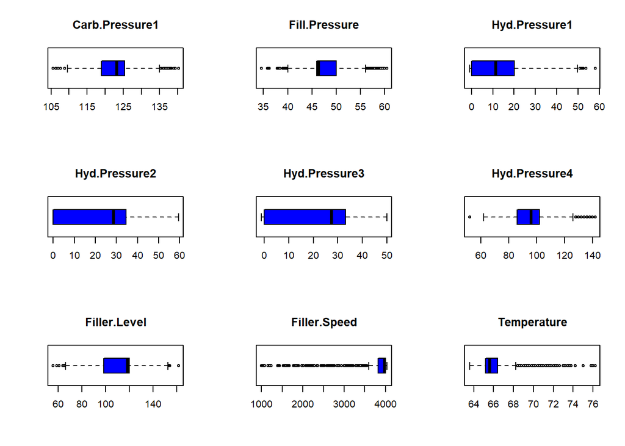

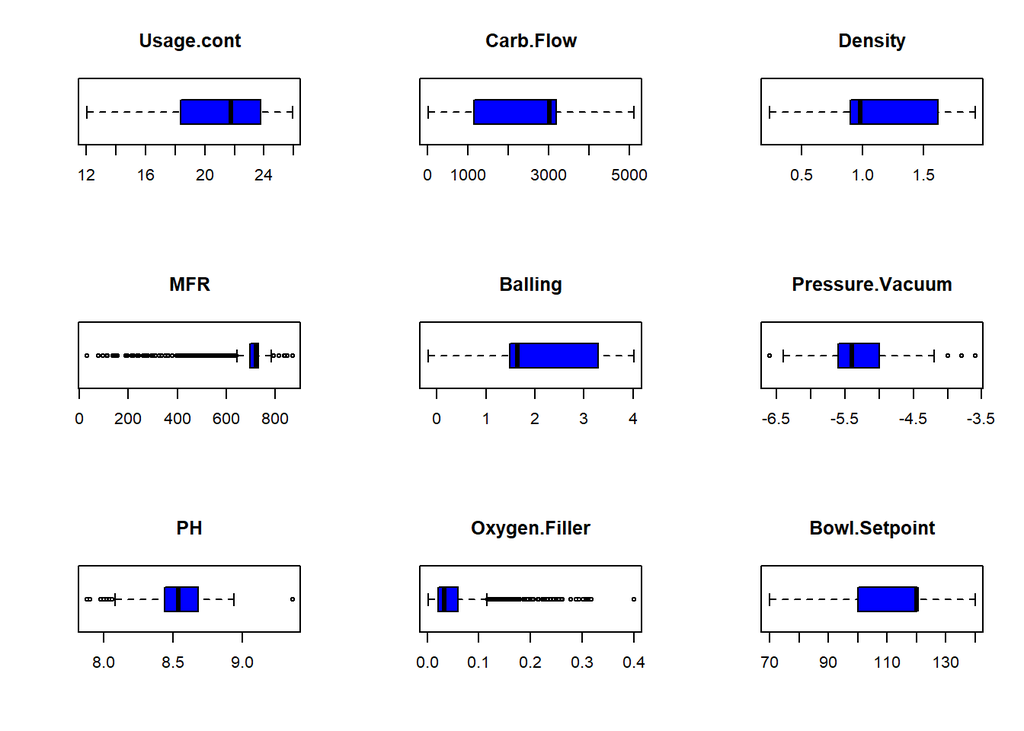

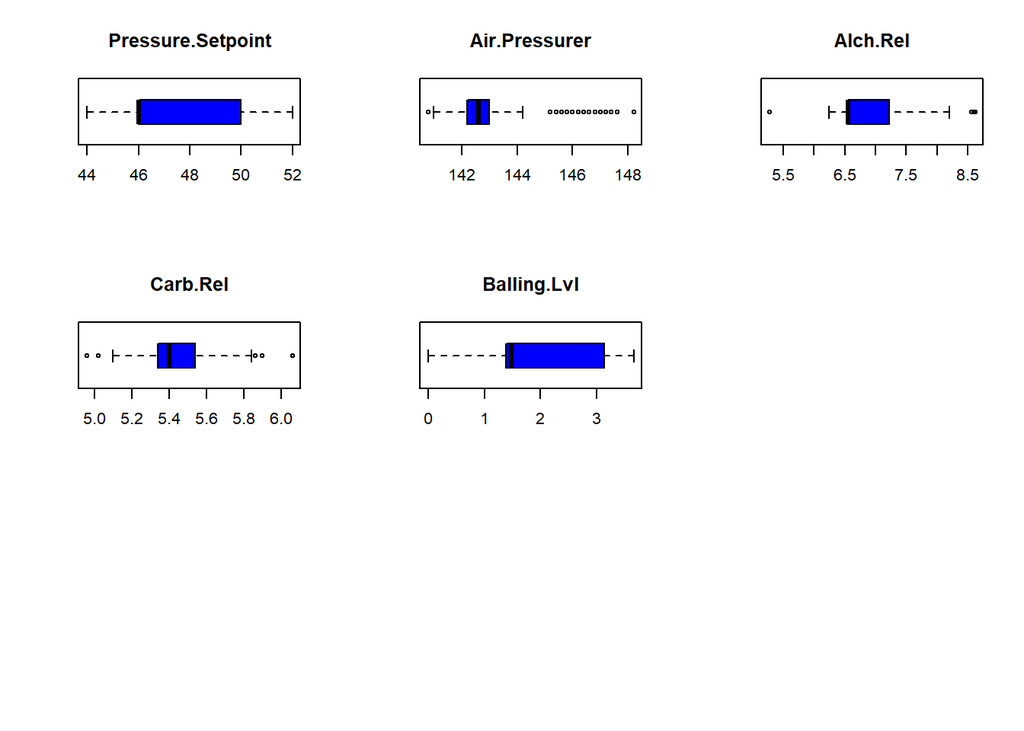

```r
par(mfrow = c(3, 3))
for(i in 2:33) {
    if (is.numeric(imputed_train[,i])) {
      boxplot(imputed_train[,i], main = names(imputed_train[i]), col = 4, horizontal = TRUE)
   }
}
```

The boxplots show that some of the variables have outliers in them. So, we’ll cap them.

```r
trainset_cap <- imputed_train

for (i in 2:33) {
  qntl <- quantile(trainset_cap[,i], probs = c(0.25, 0.75), na.rm = T)
  cap_amt <- quantile(trainset_cap[,i], probs = c(0.05, 0.95), na.rm = T)
  High <- 1.5 * IQR(trainset_cap[,i], na.rm = T)

  trainset_cap[,i][trainset_cap[,i] < (qntl[1] - High)] <- cap_amt[1]
  trainset_cap[,i][trainset_cap[,i] > (qntl[2] + High)] <- cap_amt[2]
}
```

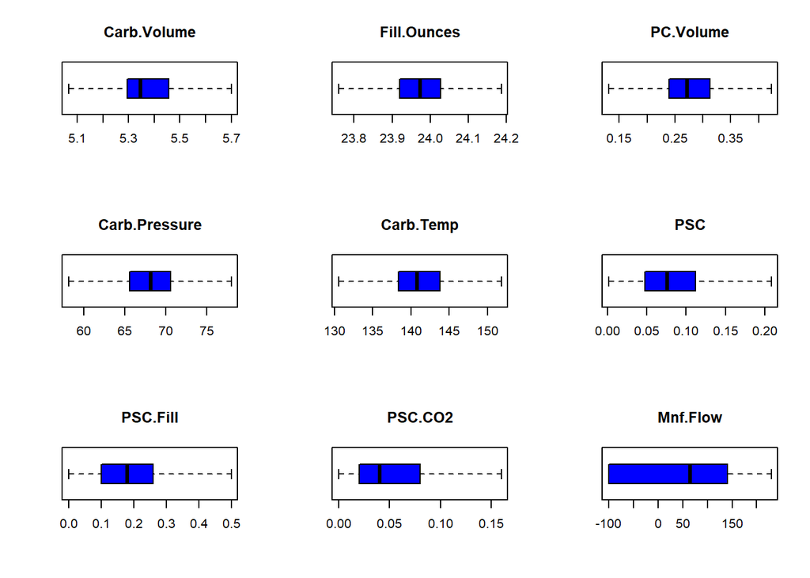

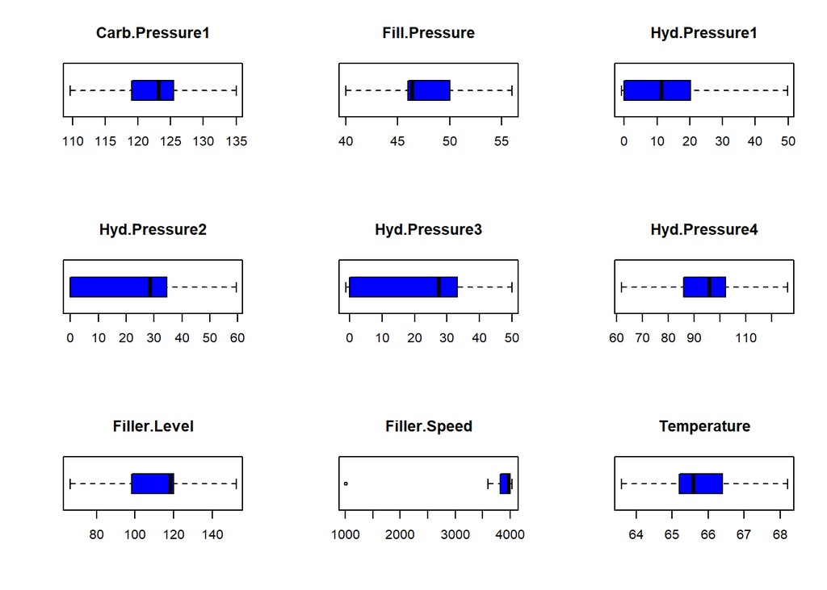

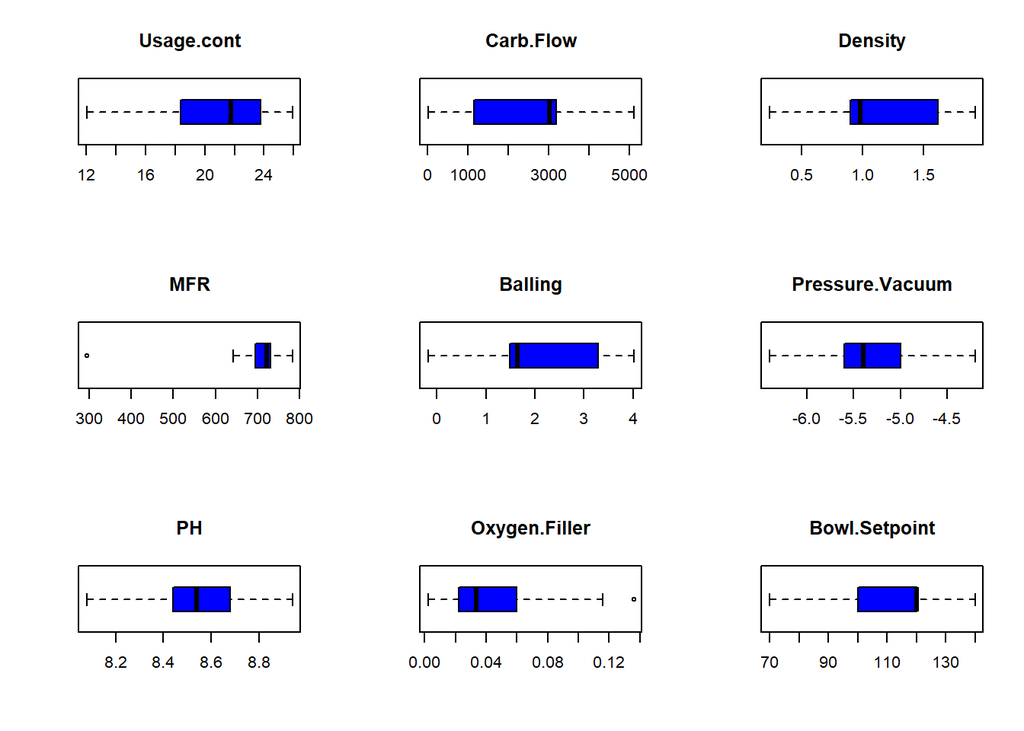

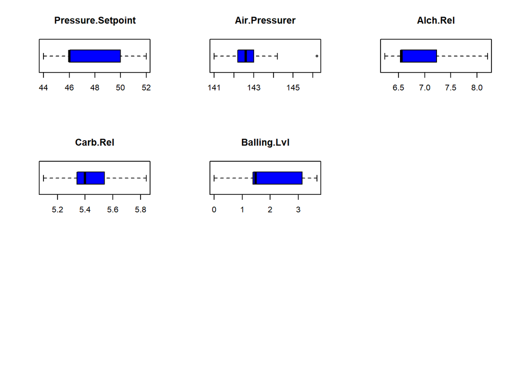

```r
par(mfrow = c(3, 3))
for(i in 2:33) {
    if (is.numeric(trainset_cap[,i])) {
      boxplot(trainset_cap[,i], main = names(trainset_cap[i]), col = 4, horizontal = TRUE)
   }
}
```

The outliers were caped and now we see that several fields PSC.FILL, PSC.C02, Mnf.Flow, Hyd.Pressure1, Hyd.Pressure2, Hyd.Pressure3, Usage.cont, Carb.Flow, Density, Balling, Oxygen.Filler, Bowl.Setpoint, Pressure.Setpoint, Alch.Rel, Balling.Lvl have high variance.

## 6.2 Histograms

Histograms tell us how the data is distributed in the dataset (numeric fields).

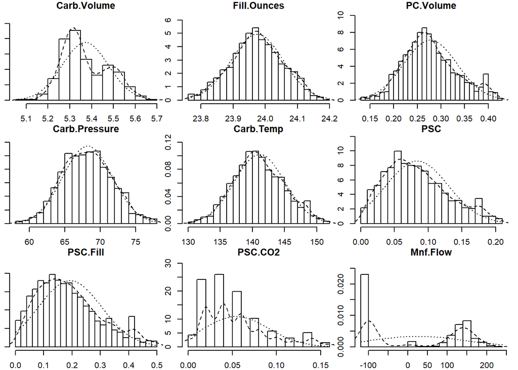

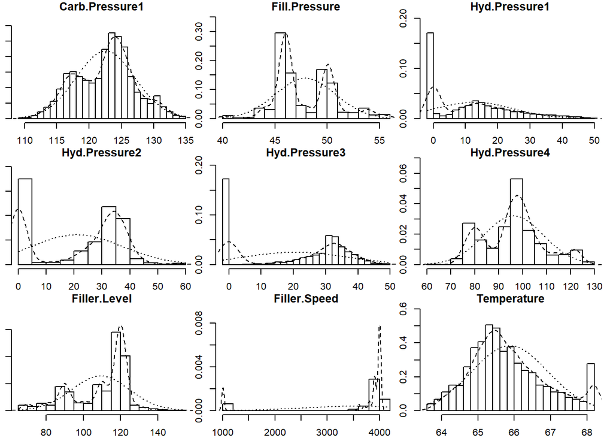

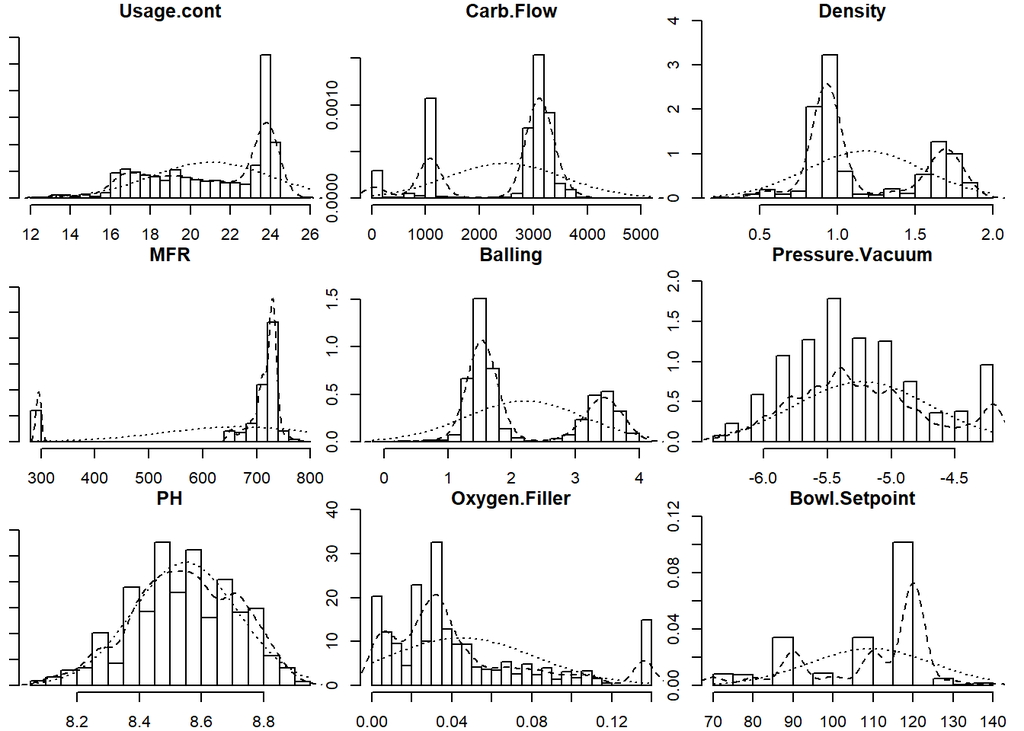

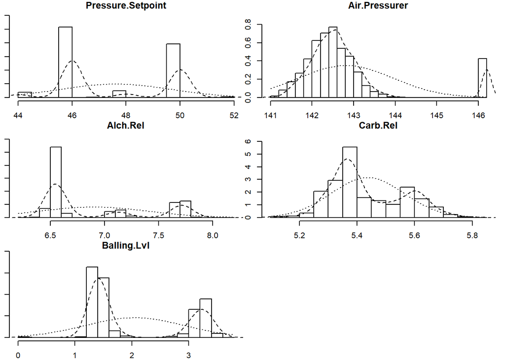

```r
for(i in seq(from = 2, to = length(trainset_cap), by = 9)) {
  if(i <= 27) {
    multi.hist(trainset_cap[i:(i + 8)])
  } else {
    multi.hist(trainset_cap[i:(i + 4)])
  }
}
```

```r
transform_cols <- c()

for(i in seq(from = 2, to = length(trainset_cap), by = 1)) {
  if(abs(skewness(trainset_cap[, i])) >= 1) {
    transform_cols <- append(transform_cols, names(trainset_cap[i]))
    print(paste0(names(trainset_cap[i]), ": ", skewness(trainset_cap[, i])))
  }
}
```

```
## [1] "Filler.Speed: -2.20552774137374"
## [1] "MFR: -2.22844789760678"
## [1] "Oxygen.Filler: 1.18860134829411"
## [1] "Air.Pressurer: 2.07962689734424"
```

Many of these histograms are skewed. So, following the recommendations of “Applied Statistical Learning” (page 105, 2nd para), I’ll apply Box-Cox transformation to remove the skewness.

```r
lambda <- NULL
data_imputed_2 <- trainset_cap

for (i in 1:length(transform_cols)) {
  lambda[transform_cols[i]] <- BoxCox.lambda(abs(trainset_cap[, transform_cols[i]]))

  data_imputed_2[c(transform_cols[i])] <- BoxCox(trainset_cap[transform_cols[i]], lambda[transform_cols[i]])
}
```

Now, we don’t need to observe the histograms all over again. It will suffice to see the skewness.

We observe that skewness of most or all of the columns reduced and some even reduced to less than 1.

```r
for(i in seq(from = 2, to = length(data_imputed_2), by = 1)) {
  if(abs(skewness(data_imputed_2[, i])) >= 1) {
    print(paste0(names(data_imputed_2[i]), ": ", skewness(data_imputed_2[, i])))
  }
}
```

```
## [1] "Filler.Speed: -2.1507244853164"
## [1] "MFR: -2.1427256132032"
## [1] "Air.Pressurer: 2.04308315860091"
```

## 6.3 Categorical variables

Now, we’ll explore the Categorical variables.

```r
cat('Brand.Code:')
```

```
## Brand.Code:
```

```r
table(data_imputed_2$Brand.Code)
```

```
##
##         A    B    C    D
##  120  293 1239  304  615
```

Observation: In Brand.Code column, 120 rows are empty. So, we’ll impute them with “X”.

```r
trainset_cap_imputed <- data_imputed_2 %>% mutate(Brand.Code = ifelse((Brand.Code == ""), "X", Brand.Code))

cat("Brand.Code:")
```

```
## Brand.Code:
```

```r
table(trainset_cap_imputed$Brand.Code)
```

```
##
##    A    B    C    D    X
##  293 1239  304  615  120
```

## 6.4 Correlations

At this point the data is prepared. So, we’ll explore the top correlated variables.

For the purpose of correlation, we’ll remove the only non-numeric field Brand.Code, out of the correlation.

Now, we’ll look at the correlation matrix of the variables.

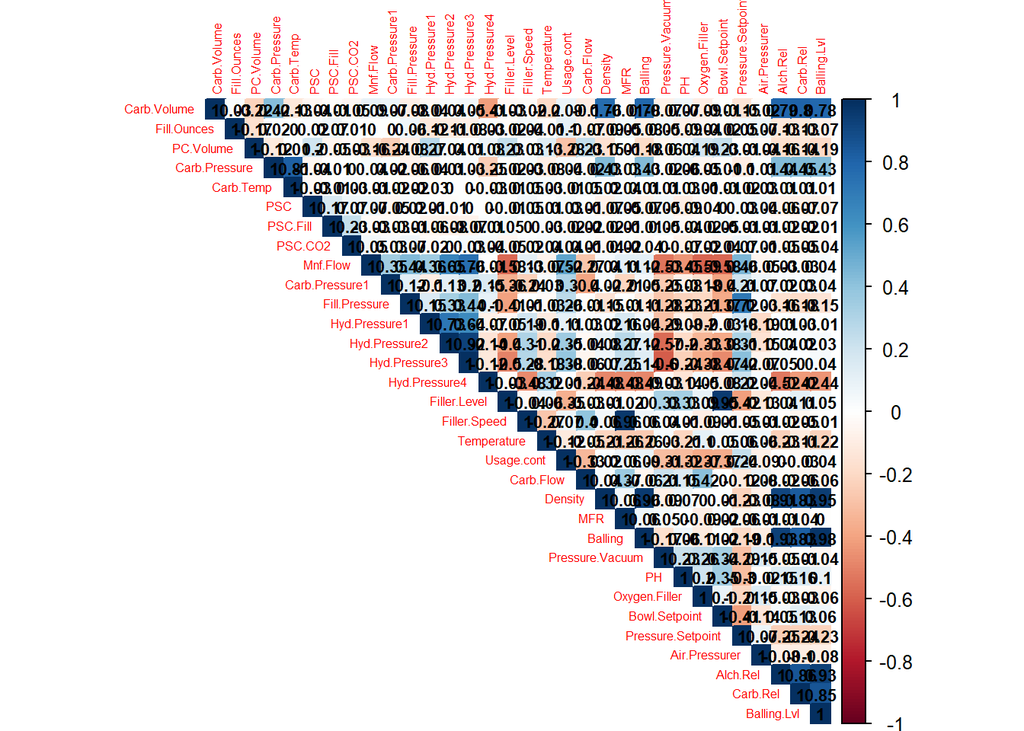

```r
trainset_corr <- trainset_cap_imputed[-1]

cor_mx = cor(trainset_corr, use = "pairwise.complete.obs", method = "pearson")

corrplot(cor_mx, method = "color", type = "upper", order = "original", number.cex = .7, addCoef.col = "black",   #Add coefficient of correlation
                            tl.srt = 90,  # Text label color and rotation
                            diag = TRUE,  # hide correlation coefficient on the principal diagonal
                            tl.cex = 0.5)
```

At this point exploration, preparation and pair-wise correlations of **StudentData.csv** are done. So, I’ll begin the same exericse for **StudentEvaluation.csv**.

# 7 Data Exploration

Initially, we’ll do a cursory exploration of the data. After that, we’ll iteratively prepare and explore the data, wherever required.

```r
dim2 <- dim(student_data_eval)
#Training set dimension - rows/ columns
dim2[1]
```

```
## [1] 267
```

```r
dim2[2]
```

```
## [1] 33
```

```r
head(student_data_eval) %>%
  kable() %>%
    kable_styling()
```

| Brand.Code | Carb.Volume | Fill.Ounces | PC.Volume | Carb.Pressure | Carb.Temp | PSC | PSC.Fill | PSC.CO2 | Mnf.Flow | Carb.Pressure1 | Fill.Pressure | Hyd.Pressure1 | Hyd.Pressure2 | Hyd.Pressure3 | Hyd.Pressure4 | Filler.Level | Filler.Speed | Temperature | Usage.cont | Carb.Flow | Density | MFR | Balling | Pressure.Vacuum | PH | Oxygen.Filler | Bowl.Setpoint | Pressure.Setpoint | Air.Pressurer | … |
| --- | --- | --- | --- | --- | --- | --- | --- | --- | --- | --- | --- | --- | --- | --- | --- | --- | --- | --- | --- | --- | --- | --- | --- | --- | --- | --- | --- | --- | --- | --- |
| D | 5.480000 | 24.03333 | 0.2700000 | 65.4 | 134.6 | 0.236 | 0.40 | 0.04 | -100 | 116.6 | 46.0 | 0 | NA | NA | 96 | 129.4 | 3986 | 66.0 | 21.66 | 2950 | 0.88 | 727.6 | 1.398 | -3.8 | NA | 0.022 | 130 | 45.2 | 142.6 | … |
| A | 5.393333 | 23.95333 | 0.2266667 | 63.2 | 135.0 | 0.042 | 0.22 | 0.08 | -100 | 118.8 | 46.2 | 0 | 0 | 0 | 112 | 120.0 | 4012 | 65.6 | 17.60 | 2916 | 1.50 | 735.8 | 2.942 | -4.4 | NA | 0.030 | 120 | 46.0 | 147.2 | … |
| B | 5.293333 | 23.92000 | 0.3033333 | 66.4 | 140.4 | 0.068 | 0.10 | 0.02 | -100 | 120.2 | 45.8 | 0 | 0 | 0 | 98 | 119.4 | 4010 | 65.6 | 24.18 | 3056 | 0.90 | 734.8 | 1.448 | -4.2 | NA | 0.046 | 120 | 46.0 | 146.6 | … |
| B | 5.266667 | 23.94000 | 0.1860000 | 64.8 | 139.0 | 0.004 | 0.20 | 0.02 | -100 | 124.8 | 40.0 | 0 | 0 | 0 | 132 | 120.2 | NA | 74.4 | 18.12 | 28 | 0.74 | NA | 1.056 | -4.0 | NA | NA | 120 | 46.0 | 146.4 | … |
| B | 5.406667 | 24.20000 | 0.1600000 | 69.4 | 142.2 | 0.040 | 0.30 | 0.06 | -100 | 115.0 | 51.4 | 0 | 0 | 0 | 94 | 116.0 | 4018 | 66.4 | 21.32 | 3214 | 0.88 | 752.0 | 1.398 | -4.0 | NA | 0.082 | 120 | 50.0 | 145.8 | … |
| B | 5.286667 | 24.10667 | 0.2120000 | 73.4 | 147.2 | 0.078 | 0.22 | NA | -100 | 118.6 | 46.4 | 0 | 0 | 0 | 94 | 120.4 | 4010 | 66.6 | 18.00 | 3064 | 0.84 | 732.0 | 1.298 | -3.8 | NA | 0.064 | 120 | 46.0 | 146.0 | … |

```r
str(student_data_eval)
```

```
## 'data.frame':    267 obs. of  33 variables:
##  $ Brand.Code       : chr  "D" "A" "B" "B" ...
##  $ Carb.Volume      : num  5.48 5.39 5.29 5.27 5.41 ...
##  $ Fill.Ounces      : num  24 24 23.9 23.9 24.2 ...
##  $ PC.Volume        : num  0.27 0.227 0.303 0.186 0.16 ...
##  $ Carb.Pressure    : num  65.4 63.2 66.4 64.8 69.4 73.4 65.2 67.4 66.8 72.6 ...
##  $ Carb.Temp        : num  135 135 140 139 142 ...
##  $ PSC              : num  0.236 0.042 0.068 0.004 0.04 0.078 0.088 0.076 0.246 0.146 ...
##  $ PSC.Fill         : num  0.4 0.22 0.1 0.2 0.3 0.22 0.14 0.1 0.48 0.1 ...
##  $ PSC.CO2          : num  0.04 0.08 0.02 0.02 0.06 NA 0 0.04 0.04 0.02 ...
##  $ Mnf.Flow         : num  -100 -100 -100 -100 -100 -100 -100 -100 -100 -100 ...
##  $ Carb.Pressure1   : num  117 119 120 125 115 ...
##  $ Fill.Pressure    : num  46 46.2 45.8 40 51.4 46.4 46.2 40 43.8 40.8 ...
##  $ Hyd.Pressure1    : num  0 0 0 0 0 0 0 0 0 0 ...
##  $ Hyd.Pressure2    : num  NA 0 0 0 0 0 0 0 0 0 ...
```

[output cut: 19 more lines]

There are few fields, which have missing values, which we’ll investigate in greater details later.

# 8 Data Preparation

At this stage, we’ll explore and prepare iteratively. Now, we’ll check for NA. After that if required, we’ll impute them.

After that we’ll show some boxplots of the numeric fields.

Checking for NA.

```r
any(is.na(student_data_eval))
```

```
## [1] TRUE
```

NA does exist. So, we’ll impute with mice().

```r
eval_imputed <- mice(student_data_eval, m = 1, method = "pmm", print = F) %>% mice::complete()
```

Rechecking for NA after imputation.

```r
any(is.na(subset(eval_imputed, select = -c(PH))))
```

```
## [1] FALSE
```

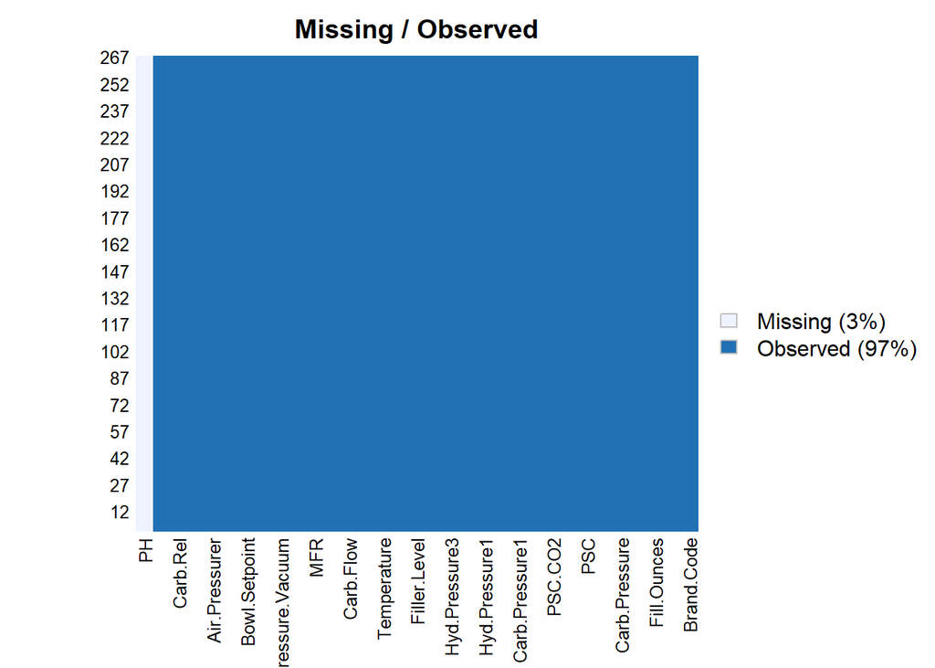

```r
eval_imputed %>% missmap(main = "Missing / Observed")
```

Now, we’ll explore the data a little further. First, we’ll take a quick look at min, 1st quartile, median, mean, 2nd quartile, max etc.

```r
summary(eval_imputed) # %>% kable
```

```
##   Brand.Code         Carb.Volume     Fill.Ounces      PC.Volume
##  Length:267         Min.   :5.147   Min.   :23.75   Min.   :0.09867
##  Class :character   1st Qu.:5.283   1st Qu.:23.92   1st Qu.:0.23333
##  Mode  :character   Median :5.340   Median :23.97   Median :0.27600
##                     Mean   :5.368   Mean   :23.97   Mean   :0.27919
##                     3rd Qu.:5.463   3rd Qu.:24.01   3rd Qu.:0.32267
##                     Max.   :5.667   Max.   :24.20   Max.   :0.46400
##  Carb.Pressure     Carb.Temp          PSC             PSC.Fill
##  Min.   :60.20   Min.   :130.0   Min.   :0.00400   Min.   :0.0200
##  1st Qu.:65.30   1st Qu.:138.4   1st Qu.:0.04500   1st Qu.:0.1000
##  Median :68.00   Median :140.8   Median :0.07800   Median :0.1800
##  Mean   :68.25   Mean   :141.3   Mean   :0.08593   Mean   :0.1897
##  3rd Qu.:70.60   3rd Qu.:143.9   3rd Qu.:0.11200   3rd Qu.:0.2500
##  Max.   :77.60   Max.   :154.0   Max.   :0.24600   Max.   :0.6200
##     PSC.CO2           Mnf.Flow       Carb.Pressure1  Fill.Pressure
##  Min.   :0.00000   Min.   :-100.20   Min.   :113.0   Min.   :37.80
##  1st Qu.:0.02000   1st Qu.:-100.00   1st Qu.:119.9   1st Qu.:46.00
##  Median :0.04000   Median :   0.20   Median :123.4   Median :47.80
##  Mean   :0.05101   Mean   :  21.03   Mean   :123.0   Mean   :48.12
##  3rd Qu.:0.06000   3rd Qu.: 141.30   3rd Qu.:125.4   3rd Qu.:50.20
##  Max.   :0.24000   Max.   : 220.40   Max.   :136.0   Max.   :60.20
##  Hyd.Pressure1    Hyd.Pressure2    Hyd.Pressure3    Hyd.Pressure4
##  Min.   :-50.00   Min.   :-50.00   Min.   :-50.00   Min.   : 68.00
##  1st Qu.:  0.00   1st Qu.:  0.00   1st Qu.:  0.00   1st Qu.: 90.00
##  Median : 10.40   Median : 26.80   Median : 27.60   Median : 98.00
##  Mean   : 12.01   Mean   : 20.04   Mean   : 19.54   Mean   : 98.23
##  3rd Qu.: 20.40   3rd Qu.: 34.80   3rd Qu.: 33.00   3rd Qu.:104.00
##  Max.   : 50.00   Max.   : 61.40   Max.   : 49.20   Max.   :140.00
##   Filler.Level    Filler.Speed   Temperature      Usage.cont      Carb.Flow
##  Min.   : 69.2   Min.   :1006   Min.   :63.80   Min.   :12.90   Min.   :   0
##  1st Qu.:100.6   1st Qu.:3795   1st Qu.:65.40   1st Qu.:18.10   1st Qu.:1083
##  Median :118.6   Median :3918   Median :65.80   Median :21.40   Median :3038
##  Mean   :110.6   Mean   :3503   Mean   :66.28   Mean   :20.88   Mean   :2409
##  3rd Qu.:120.2   3rd Qu.:3996   3rd Qu.:66.60   3rd Qu.:23.74   3rd Qu.:3215
##  Max.   :153.2   Max.   :4020   Max.   :75.40   Max.   :24.60   Max.   :3858
##     Density           MFR           Balling      Pressure.Vacuum
##  Min.   :0.060   Min.   : 15.6   Min.   :0.902   Min.   :-6.400
##  1st Qu.:0.910   1st Qu.:688.1   1st Qu.:1.498   1st Qu.:-5.600
##  Median :0.980   Median :720.6   Median :1.648   Median :-5.200
##  Mean   :1.175   Mean   :650.8   Mean   :2.201   Mean   :-5.176
##  3rd Qu.:1.600   3rd Qu.:730.8   3rd Qu.:3.242   3rd Qu.:-4.800
##  Max.   :1.840   Max.   :784.8   Max.   :3.788   Max.   :-3.600
##     PH          Oxygen.Filler     Bowl.Setpoint   Pressure.Setpoint
##  Mode:logical   Min.   :0.00240   Min.   : 70.0   Min.   :44.00
##  NA's:267       1st Qu.:0.01960   1st Qu.:100.0   1st Qu.:46.00
##                 Median :0.03380   Median :120.0   Median :46.00
##                 Mean   :0.04712   Mean   :109.7   Mean   :47.73
##                 3rd Qu.:0.05630   3rd Qu.:120.0   3rd Qu.:50.00
##                 Max.   :0.39800   Max.   :130.0   Max.   :52.00
##  Air.Pressurer      Alch.Rel        Carb.Rel      Balling.Lvl
##  Min.   :141.2   Min.   :6.400   Min.   :5.180   Min.   :0.000
##  1st Qu.:142.2   1st Qu.:6.540   1st Qu.:5.340   1st Qu.:1.380
##  Median :142.6   Median :6.580   Median :5.400   Median :1.480
##  Mean   :142.8   Mean   :6.902   Mean   :5.441   Mean   :2.051
##  3rd Qu.:142.8   3rd Qu.:7.180   3rd Qu.:5.560   3rd Qu.:3.080
##  Max.   :147.2   Max.   :7.820   Max.   :5.740   Max.   :3.420
```

## 8.1 Zeroing PH column

Currently, PH has NA. We’ll insert zero into column PH, for convenience of analysis.

```r
eval_imputed$PH[is.na(eval_imputed$PH)] <- 0
```

## 8.2 Boxplots

Let’s take a first look at the boxplots

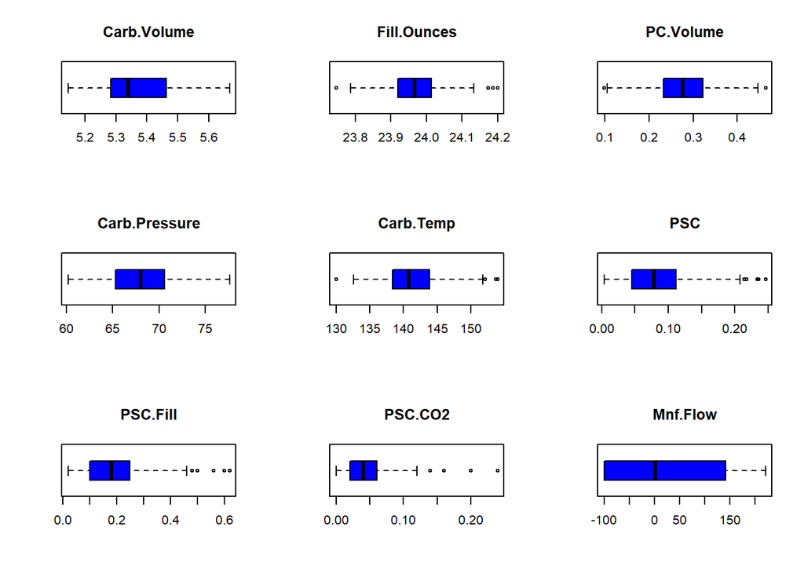

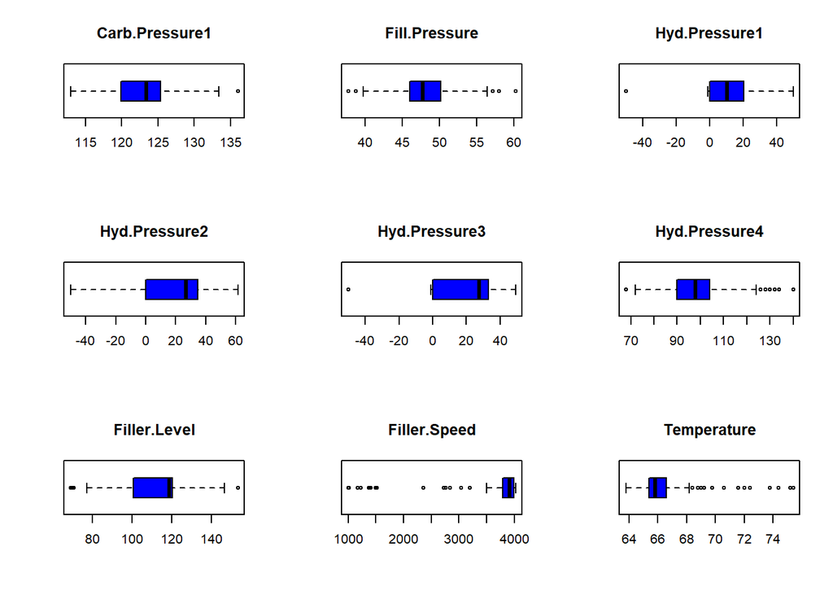

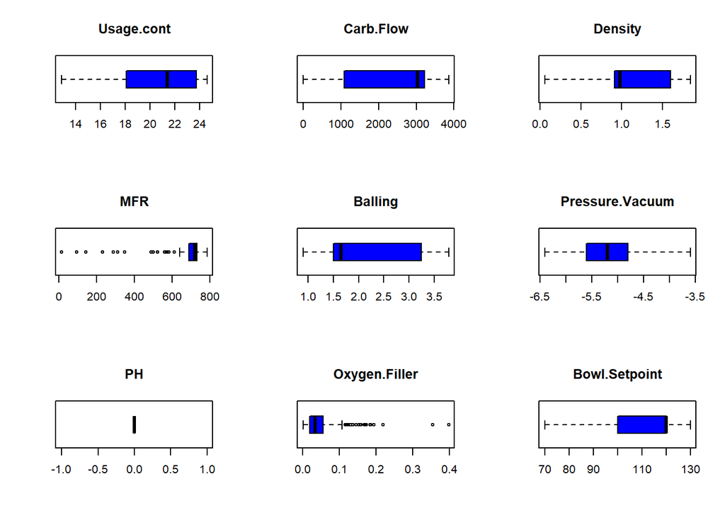

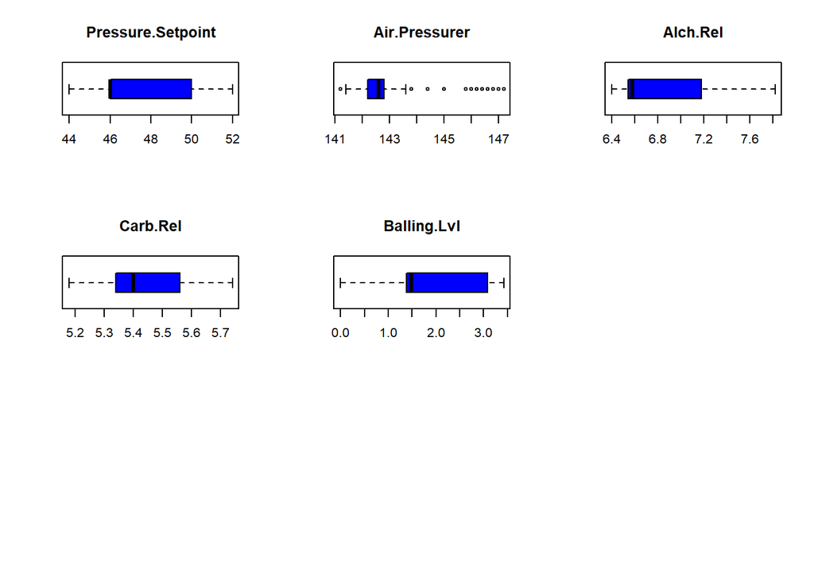

```r
par(mfrow = c(3, 3))
for(i in 2:33) {
    if (is.numeric(eval_imputed[,i])) {
      boxplot(eval_imputed[,i], main = names(eval_imputed[i]), col = 4, horizontal = TRUE)
   }
}
```

The boxplots show that some of the variables have outliers in them. So, we’ll cap them.

```r
eval_cap <- eval_imputed

for (i in 2:33) {
  if(i == 26) next # skipping the PH column, which is a 26th column position.

  qntl <- quantile(eval_cap[,i], probs = c(0.25, 0.75), na.rm = T)
  cap_amt <- quantile(eval_cap[,i], probs = c(0.05, 0.95), na.rm = T)
  High <- 1.5 * IQR(eval_cap[,i], na.rm = T)

  eval_cap[,i][eval_cap[,i] < (qntl[1] - High)] <- cap_amt[1]
  eval_cap[,i][eval_cap[,i] > (qntl[2] + High)] <- cap_amt[2]
}
```

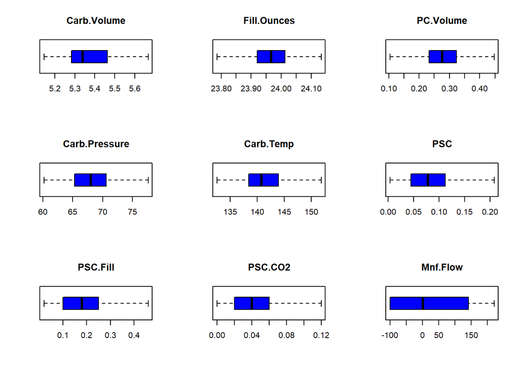

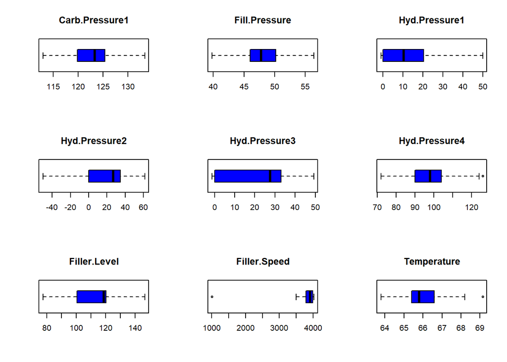

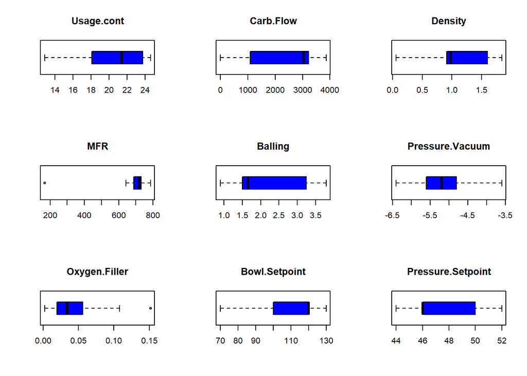

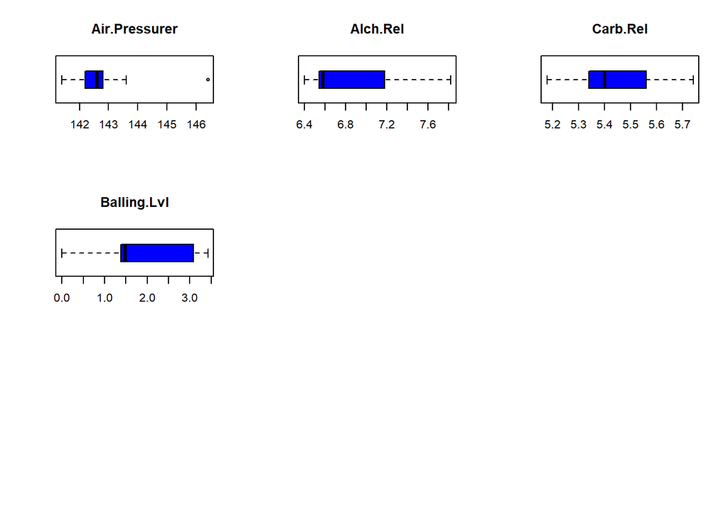

```r
par(mfrow = c(3, 3))
for(i in 2:33) {
  if(i == 26) next # skipping the PH column, which is a 26th column position.

    if (is.numeric(eval_cap[,i])) {
      boxplot(eval_cap[,i], main = names(eval_cap[i]), col = 4, horizontal = TRUE)
   }
}
```

The outliers were caped and now we see that several fields Carb.Volume, PSC.FILL, PSC.C02, Mnf.Flow, Hyd.Pressure1, Hyd.Pressure2, Hyd.Pressure3, Usage.cont, Carb.Flow, Density, Balling, Bowl.Setpoint, Pressure.Setpoint, Alch.Rel, Carb.Rel, Balling.Lvl have high variance.

## 8.3 Histograms

Histograms tell us how the data is distributed in the dataset (numeric fields).

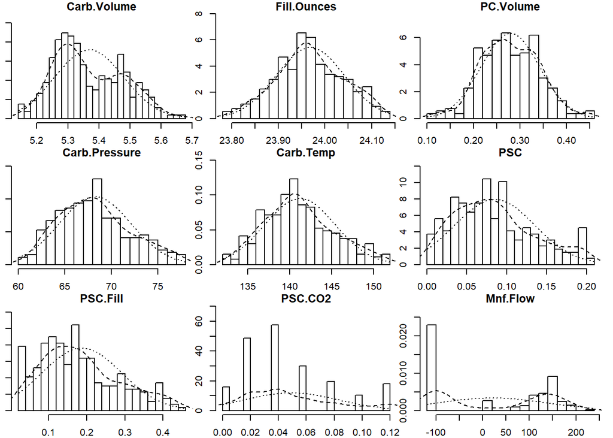

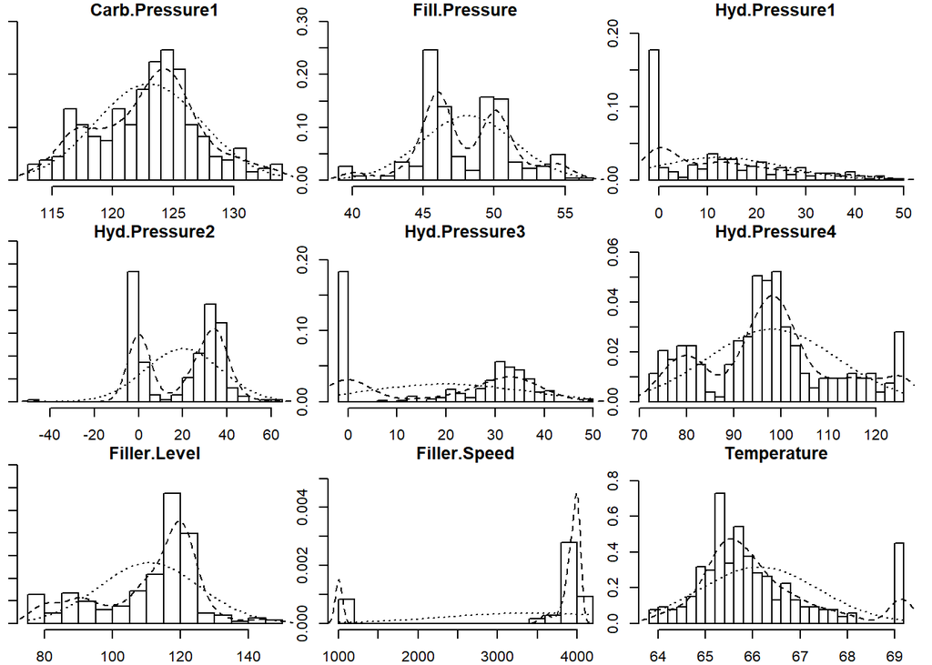

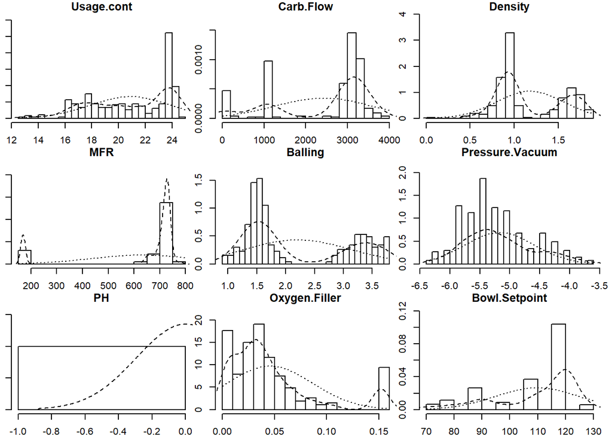

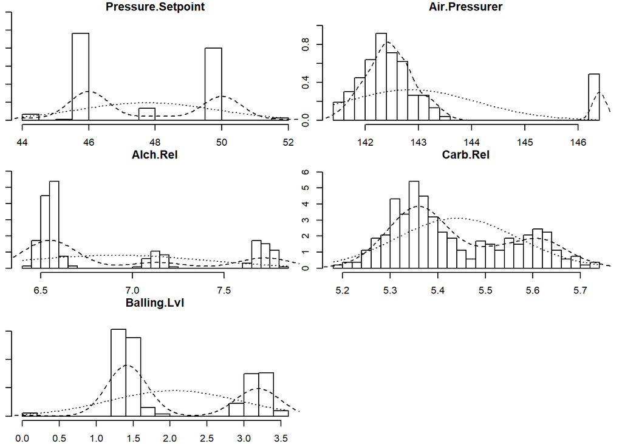

```r
for(i in seq(from = 2, to = length(eval_cap), by = 9)) {
  if(i <= 27) {
    multi.hist(eval_cap[i:(i + 8)])
  } else {
    multi.hist(eval_cap[i:(i + 4)])
  }
}
```

We can ignore PH, which is target column, where zeros were forced in.

```r
transform_cols2 <- c()

for(i in seq(from = 2, to = length(eval_cap), by = 1)) {
  if(i == 26) next # skipping the PH column, which is a 26th column position.

  if(abs(skewness(eval_cap[, i])) >= 1) {
   transform_cols2 <- append(transform_cols2, names(eval_cap[i]))
   print(paste0(names(eval_cap[i]), ": ", skewness(eval_cap[, i])))
  }
}
```

```
## [1] "Filler.Speed: -1.73092282282849"
## [1] "Temperature: 1.02507951179823"
## [1] "MFR: -1.85885777238722"
## [1] "Oxygen.Filler: 1.49592057659254"
## [1] "Bowl.Setpoint: -1.11822117605216"
## [1] "Air.Pressurer: 2.13759060366289"
```

Many of these histograms are skewed. So, following the recommendations of “Applied Statistical Learning” (page 105, 2nd para), I’ll apply Box-Cox transformation to remove the skewness.

```r
lambda <- NULL
data_imputed_3 <- eval_cap

for (i in 1:length(transform_cols2)) {
  lambda[transform_cols2[i]] <- BoxCox.lambda(abs(eval_cap[, transform_cols2[i]]))

  data_imputed_3[c(transform_cols2[i])] <- BoxCox(eval_cap[transform_cols2[i]], lambda[transform_cols2[i]])
}
```

Now, we don’t need to observe the histograms all over again. It will suffice to see the skewness.

We observe that skewness of most or all of the columns reduced and some even reduced to less than 1.

```r
for(i in seq(from = 2, to = length(data_imputed_3), by = 1)) {
  if(i == 26) next # skipping the PH column, which is a 26th column position.

  if(abs(skewness(data_imputed_3[, i])) >= 1) {
    print(paste0(names(data_imputed_3[i]), ": ", skewness(data_imputed_3[, i])))
  }
}
```

```
## [1] "Filler.Speed: -1.69187557215137"
## [1] "MFR: -1.785428838364"
## [1] "Air.Pressurer: 2.11099874571003"
```

## 8.4 Categorical variables

Now, we’ll explore the Categorical variables.

```r
cat('Brand.Code:')
```

```
## Brand.Code:
```

```r
table(data_imputed_3$Brand.Code)
```

```
##
##       A   B   C   D
##   8  35 129  31  64
```

```r
imputed_eval_cap <- data_imputed_3 %>% mutate(Brand.Code = ifelse((Brand.Code == ""), "X", Brand.Code))

cat("Brand.Code:")
```

```
## Brand.Code:
```

```r
table(imputed_eval_cap$Brand.Code)
```

```
##
##   A   B   C   D   X
##  35 129  31  64   8
```

## 8.5 Correlations

At this point the data is prepared. So, we’ll explore the top correlated variables.

For the purpose of correlation, we’ll remove the only non-numeric field Brand.Code, out of the correlation.

Now, we’ll look at the correlation matrix of the variables.

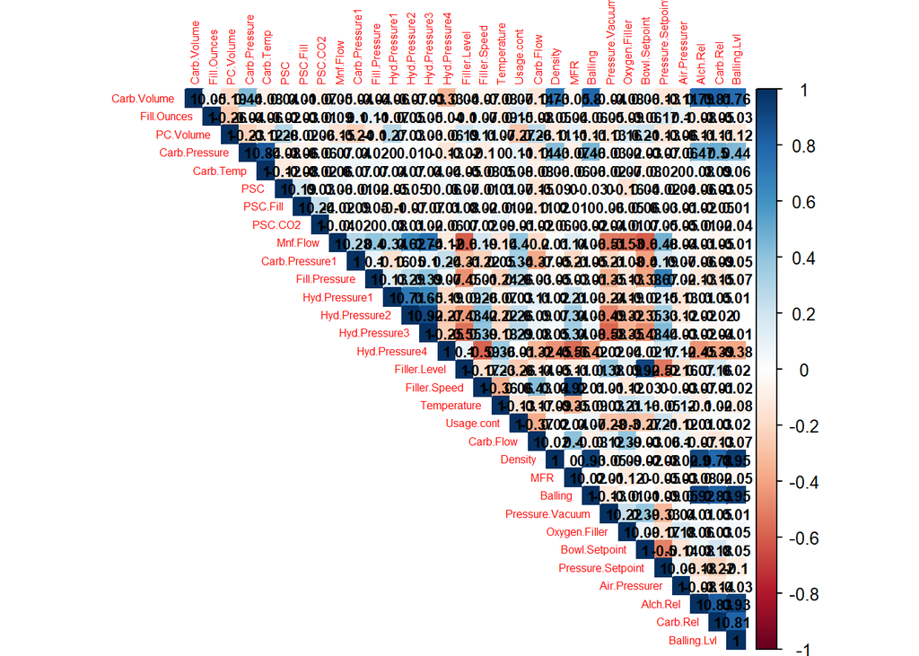

```r
Ins_cap_corr <- subset(imputed_eval_cap, select = -c(Brand.Code, PH))

cor_mx = cor(Ins_cap_corr, use = "pairwise.complete.obs", method = "pearson")

corrplot(cor_mx, method = "color", type = "upper", order = "original", number.cex = .7, addCoef.col = "black",   #Add coefficient of correlation
                            tl.srt = 90,  # Text label color and rotation
                            diag = TRUE,  # hide correlation coefficient on the principal diagonal
                            tl.cex = 0.5)
```

At this point exploration, preparation and pair-wise correlations of **StudentEvaluation.csv** are done. So, I’ll begin the building process.

# 9 Models

## 9.1 Split Data

Split test and train data. We will use 80/20 split to create Test and Train data from our trainset_cap_imputed file. Since our dataset is not that large, we want to have as much training data available for modeling as possible.

```r
set.seed(300)
trainingRows <- createDataPartition(trainset_cap_imputed$PH, p = 0.8, list = FALSE)
trainset <- trainset_cap_imputed[trainingRows, ]
testset <- trainset_cap_imputed[-trainingRows, ]

trainset_Y <- subset( trainset, select = PH )
trainset_X <- subset( trainset, select = -PH )
testset_Y <- subset( testset, select = PH )
testset_X <- subset( testset, select = -PH )
```

## 9.2 Linear Models

First we are going to try to use linear models to predict the relationship between our predictors and PH values, assuming that the relationship shows a constant rate of change. We do not have very high hopes for these models since there are a lot of limitations associated with Linear Models - in the real world, the data is rarely linearly separable.

### 9.2.1 GLM Model

First, we will try Generalized Linear model. The GLM generalizes linear regression by allowing the linear model to be related to the response variable via a link function and by allowing the magnitude of the variance of each measurement to be a function of its predicted value.

```r
set.seed(300)
lmFit1 = train(PH ~ ., data = trainset,
                      metric = 'RMSE',
                      method = 'glm',
                      preProcess = c('center', 'scale'),
                      trControl = trainControl(method = 'cv', number = 5, savePredictions = TRUE)
)

lmFit1_pred <- predict(lmFit1, testset_X)

lmFit1
```

```
## Generalized Linear Model
##
## 2058 samples
##   32 predictor
##
## Pre-processing: centered (35), scaled (35)
## Resampling: Cross-Validated (5 fold)
## Summary of sample sizes: 1648, 1647, 1645, 1645, 1647
## Resampling results:
##
##   RMSE       Rsquared  MAE
##   0.1289845  0.413532  0.1012006
```

### 9.2.2 PLS Model

Next, we will try Partial Least Squares model. PSL finds a linear regression model by projecting the predicted variables and the observable variables to a new space. If the correlation among predictors is high, then the partial least squares squares might be a better option. PSL might also be better is the number of predictors may be greater than the number of observations.

```r
set.seed(300)
lmFit2 = train(PH ~ ., data = trainset,
                      metric = 'RMSE',
                      method = 'pls',
                      preProcess = c('center', 'scale'),
                      trControl = trainControl(method = 'cv', number = 5, savePredictions = TRUE)
)

lmFit2_pred <- predict(lmFit2, testset_X)

lmFit2
```

```
## Partial Least Squares
##
## 2058 samples
##   32 predictor
##
## Pre-processing: centered (35), scaled (35)
## Resampling: Cross-Validated (5 fold)
## Summary of sample sizes: 1648, 1647, 1645, 1645, 1647
## Resampling results across tuning parameters:
##
##   ncomp  RMSE       Rsquared   MAE
##   1      0.1453335  0.2534021  0.1156337
##   2      0.1374283  0.3331055  0.1082846
##   3      0.1345183  0.3607339  0.1068518
##
## RMSE was used to select the optimal model using the smallest value.
## The final value used for the model was ncomp = 3.
```

The PLS R-Squared value is not very high - 0.37, meaning that the model explains 37% of variability in the data. RMSE for PLS is 0.132.

### 9.2.3 Ridge Model

Next, we will try some penalized models, we will start with a Ridge model. Ridge regression adds a penalty on the sum of the squared regression parameters.

```r
set.seed(300)
ridgeGrid <- data.frame(.lambda = seq(0, .1, length = 15))
ridgeRegFit <- train(x = trainset_X[,-1], y = trainset_Y$PH,
                      method = "ridge",
                      tuneGrid = ridgeGrid,
                      trControl = trainControl(method = "cv", number = 10),
                      preProc = c("center", "scale")
                     )
ridgeRegFit
```

```
## Ridge Regression
##
## 2058 samples
##   31 predictor
##
## Pre-processing: centered (31), scaled (31)
## Resampling: Cross-Validated (10 fold)
## Summary of sample sizes: 1852, 1853, 1852, 1853, 1853, 1852, ...
## Resampling results across tuning parameters:
##
##   lambda       RMSE       Rsquared   MAE
##   0.000000000  0.1345576  0.3602601  0.1048016
##   0.007142857  0.1345558  0.3601130  0.1048612
##   0.014285714  0.1346343  0.3593354  0.1050278
##   0.021428571  0.1347298  0.3584184  0.1051884
##   0.028571429  0.1348317  0.3574445  0.1053364
##   0.035714286  0.1349361  0.3564459  0.1054770
##   0.042857143  0.1350411  0.3554406  0.1056126
##   0.050000000  0.1351454  0.3544392  0.1057435
##   0.057142857  0.1352485  0.3534486  0.1058704
##   0.064285714  0.1353501  0.3524729  0.1059860
##   0.071428571  0.1354499  0.3515145  0.1060969
##   0.078571429  0.1355479  0.3505750  0.1062028
##   0.085714286  0.1356440  0.3496550  0.1063058
##   0.092857143  0.1357384  0.3487546  0.1064027
##   0.100000000  0.1358312  0.3478737  0.1064957
##
## RMSE was used to select the optimal model using the smallest value.
## The final value used for the model was lambda = 0.007142857.
```

```r
ridge_pred <- predict(ridgeRegFit, testset_X)
```

### 9.2.4 ENET Model

Next, we will try ENET model. Elastic net model has both ridge penalties and lasso penalties.

```r
df1_enet <-  train(x = as.matrix(trainset_X[,-1]),
                 y = trainset_Y$PH,
                 method='enet',
                 metric='RMSE',
                 trControl = trainControl(method = 'cv', number = 5, savePredictions = TRUE))

df1_enet
```

```
## Elasticnet
##
## 2058 samples
##   31 predictor
##
## No pre-processing
## Resampling: Cross-Validated (5 fold)
## Summary of sample sizes: 1645, 1646, 1646, 1648, 1647
## Resampling results across tuning parameters:
##
##   lambda  fraction  RMSE       Rsquared   MAE
##   0e+00   0.050     0.1552325  0.2036363  0.1251836
##   0e+00   0.525     0.1350769  0.3548269  0.1056261
##   0e+00   1.000     0.1344532  0.3605568  0.1047141
##   1e-04   0.050     0.1552575  0.2033934  0.1252063
##   1e-04   0.525     0.1350850  0.3547596  0.1056362
##   1e-04   1.000     0.1344518  0.3605656  0.1047137
##   1e-01   0.050     0.1600931  0.2000477  0.1297234
##   1e-01   0.525     0.1386294  0.3207258  0.1095320
##   1e-01   1.000     0.1357622  0.3475730  0.1064151
##
## RMSE was used to select the optimal model using the smallest value.
## The final values used for the model were fraction = 1 and lambda = 1e-04.
```

```r
enet_pred <- predict(df1_enet, testset_X)
```

### 9.2.5 Comparing Linear Models

As expected, it doesn’t look like either of the linear models has a good performance based on their R-squared and RMSE values, but let’s compare those and see which model performs best.

```r
z<- rbind(
  postResample(pred = lmFit1_pred, obs = testset_Y$PH),
  postResample(pred = lmFit2_pred, obs = testset_Y$PH),
  postResample(pred = ridge_pred, obs = testset_Y$PH),
  postResample(pred = enet_pred, obs = testset_Y$PH)
)

data.frame(z,row.names = c('GLM', 'PLS', 'RIDGE', 'ENET'))
```

```
##            RMSE  Rsquared       MAE
## GLM   0.1268847 0.4254438 0.1012708
## PLS   0.1328558 0.3698879 0.1078396
## RIDGE 0.1313080 0.3843029 0.1030508
## ENET  0.1313191 0.3843768 0.1027928
```

The best linear model based on the highest R-Squared and lowest RSME value is GLM.

## 9.3 Non-Linear Models

Next we will try several Non-Linear models:multivariate adaptive regression splines (MARS), support vector machines (SVMs), and K-nearest neighbors (KNNs). We expect these models to perform better than Linear Models. We will look at Tree models separately.

### 9.3.1 MARS Model

We will continue modeling by tuning and evaluating a MARS model. MARS uses surrogate features instead of the original predictors.

```r
set.seed(200)
marsGrid <- expand.grid(.degree = 1:2, .nprune = 2:20)
marsTune <- train(x = trainset_X,
                  y = trainset_Y$PH,
                  method = "earth",
                  preProc=c("center", "scale"),
                  tuneGrid= marsGrid,
                  trControl = trainControl(method = "cv"))
```

Evaluating MARS model’s performance:

```r
marsPred = predict(marsTune, newdata = testset_X)
postResample(pred = marsPred, obs = testset_Y$PH)
```

```
##       RMSE   Rsquared        MAE
## 0.11982919 0.48729858 0.09213765
```

### 9.3.2 SVM Model

The next model we will tune and evaluate is SVM model - we will use pre-process to center and scale the data and will use tune length of 10. The benefist of SVM are that, since the squared residuals are not used, large outliers have a limited effect on the regression equation. Second, samples that the model fits well have no effect on the regression equation.

```r
set.seed(200)
svmTuned = train(x = trainset_X[,-1],
                 y = trainset_Y$PH,
                 method="svmRadial",
                 preProc=c("center", "scale"),
                 tuneLength=10,
                 trControl = trainControl(method = "repeatedcv"))

svmTuned
```

```
## Support Vector Machines with Radial Basis Function Kernel
##
## 2058 samples
##   31 predictor
##
## Pre-processing: centered (31), scaled (31)
## Resampling: Cross-Validated (10 fold, repeated 1 times)
## Summary of sample sizes: 1852, 1851, 1853, 1852, 1853, 1853, ...
## Resampling results across tuning parameters:
##
##   C       RMSE       Rsquared   MAE
##     0.25  0.1263663  0.4430938  0.09464080
##     0.50  0.1232904  0.4670949  0.09125210
##     1.00  0.1210120  0.4852533  0.08891841
##     2.00  0.1193498  0.4994648  0.08777003
##     4.00  0.1186035  0.5069352  0.08711807
##     8.00  0.1193552  0.5050925  0.08780227
##    16.00  0.1218473  0.4941590  0.08982140
##    32.00  0.1259518  0.4758255  0.09351532
##    64.00  0.1305571  0.4561023  0.09793995
##   128.00  0.1361970  0.4329529  0.10257001
##
## Tuning parameter 'sigma' was held constant at a value of 0.02216765
## RMSE was used to select the optimal model using the smallest value.
## The final values used for the model were sigma = 0.02216765 and C = 4.
```

```r
SVMPred = predict(svmTuned, newdata = testset_X[,-1])
postResample(pred = SVMPred, obs = testset_Y$PH)
```

```
##       RMSE   Rsquared        MAE
## 0.11885681 0.50320438 0.08603814
```

### 9.3.3 KNN Model

The next Non-Linear model we will tune and evaluate is KNN model. The KNN approach predicts a new sample using the K-closest samples from the training set.

```r
set.seed(333)
knnModel <- train(x = trainset_X[,-1],
                 y = trainset_Y$PH,
                 method = "knn",
                 preProc = c("center", "scale"),
                 tuneLength = 10)
knnModel
```

```
## k-Nearest Neighbors
##
## 2058 samples
##   31 predictor
##
## Pre-processing: centered (31), scaled (31)
## Resampling: Bootstrapped (25 reps)
## Summary of sample sizes: 2058, 2058, 2058, 2058, 2058, 2058, ...
## Resampling results across tuning parameters:
##
##   k   RMSE       Rsquared   MAE
##    5  0.1364097  0.3733673  0.10050576
##    7  0.1329826  0.3906458  0.09887772
##    9  0.1312364  0.4005157  0.09829267
##   11  0.1302996  0.4063066  0.09807803
##   13  0.1300757  0.4072699  0.09844349
##   15  0.1304589  0.4034700  0.09910582
##   17  0.1306388  0.4017684  0.09964254
##   19  0.1308768  0.3998936  0.10009655
##   21  0.1313424  0.3957608  0.10076540
##   23  0.1317725  0.3920796  0.10142116
##
## RMSE was used to select the optimal model using the smallest value.
## The final value used for the model was k = 13.
```

Evaluating the model’s performance:

```r
knnPred <- predict(knnModel, newdata = testset_X[,-1])
postResample(pred = knnPred, obs = testset_Y$PH)
```

```
##       RMSE   Rsquared        MAE
## 0.12274908 0.46738179 0.09313305
```

### 9.3.4 Comparing Non-Linear Models

It looks like non-linear models are performing better than the linear models based on their R-squared values, but let’s compare those and see which model performs best.

```r
z<- rbind(
  postResample(pred = marsPred, obs = testset_Y$PH),
  postResample(pred = SVMPred, obs = testset_Y$PH),
  postResample(pred = knnPred, obs = testset_Y$PH)
)

data.frame(z,row.names = c('MARS', 'SVM', 'KNN'))
```

```
##           RMSE  Rsquared        MAE
## MARS 0.1198292 0.4872986 0.09213765
## SVM  0.1188568 0.5032044 0.08603814
## KNN  0.1227491 0.4673818 0.09313305
```

## 9.4 Tree Models

We will now try some Tree models. Decision tree analysis involves making a tree-shaped diagram to chart out a course of action or a statistical probability analysis. It is used to break down complex problems or branches. Each branch of the decision tree could be a possible outcome.

### 9.4.1 Random Forest

First, we will try a Random Forest Model, these model achieves variance reduction by selecting strong, complex learners that exhibit low bias. Because each learner is selected independently of all previous learners, random forests is robust to a noisy response.

```r
suppressWarnings(library(randomForest))
set.seed(333)
RF_model <- randomForest(x = trainset_X[,-1],
                  y = trainset_Y$PH,
                  importance = TRUE,
                  ntree = 700
                  )

RFPred <- predict(RF_model, newdata = testset_X[,-1])
postResample(pred = RFPred, obs = testset_Y$PH)
```

```
##       RMSE   Rsquared        MAE
## 0.09717654 0.68470460 0.07131481
```

### 9.4.2 Boosted trees

Next, we will try a Boosted Tree Model. The basic principles of gradient boosting are as follows: given a loss function (e.g., squared error for regression) and a weak learner (e.g., regression trees), the algorithm seeks to find an additive model that minimizes the loss function.

```r
suppressWarnings(library(gbm))
set.seed(333)
gbmGrid <- expand.grid(.interaction.depth = seq(1, 5, by = 2),
                       .n.trees = seq(300, 1000, by = 100),
                       .shrinkage = c(0.05, 0.1),
                       .n.minobsinnode = 5)

gbmTune <- suppressWarnings(train(trainset_X[,-1], trainset_Y$PH,
                method = "gbm",
                tuneGrid = gbmGrid,
                verbose = FALSE)
                )

GBM_Pred <- predict(gbmTune, newdata = testset_X[,-1])
postResample(pred = GBM_Pred, obs = testset_Y$PH)
```

```
##       RMSE   Rsquared        MAE
## 0.10251394 0.62594625 0.07640238
```

### 9.4.3 Single Tree

Next, we will try a Single Tree Model. Basic regression trees partition the data into smaller groups that are more homogenous with respect to the response.

```r
set.seed(333)
rpartTune <- train(trainset_X, trainset_Y$PH,
                   method = "rpart2",
                   tuneLength = 10,
                   trControl = trainControl(method = "cv"))

ST_Pred <- predict(rpartTune, newdata = testset_X)
postResample(pred = ST_Pred, obs = testset_Y$PH)
```

```
##       RMSE   Rsquared        MAE
## 0.12559793 0.43790751 0.09825311
```

#### 9.4.3.1 Cubist

Next, we will try a Cubist Model. Cubist is a rule–based model. A tree is grown where the terminal leaves contain linear regression models. These models are based on the predictors used in previous splits. Also, there are intermediate linear models at each step of the tree.

```r
suppressWarnings(library(Cubist))
set.seed(333)

cubistMod <- cubist(trainset_X,
                    trainset_Y$PH,
                    committees = 6
)

cubistModPred <- predict(cubistMod, newdata = testset_X)
postResample(pred = cubistModPred, obs = testset_Y$PH)
```

```
##      RMSE  Rsquared       MAE
## 0.1103035 0.6144539 0.0771833
```

### 9.4.4 Bagged Trees

Finally, we will try Bagged Trees Model. Bagging effectively reduces the variance of a prediction through its aggregation process.

```r
set.seed(333)
suppressWarnings(library(ipred))

baggedTree <- ipredbagg(trainset_Y$PH, trainset_X)

baggedTreePred <- predict(baggedTree, newdata = testset_X)
postResample(pred = baggedTreePred, obs = testset_Y$PH)
```

```
##       RMSE   Rsquared        MAE
## 0.11417348 0.53871727 0.08954798
```